# Week 6 Tuesday – Using nhanes survey data to examine racial differences in blood lead levels in children

### **Introduction**

Today, we will work with the National Health and Nutrition Examination Survey (nhanes) data from the USA National Center for Health Statistics (https://www.cdc.gov/nchs/nhanes/about_nhanes.htm). As preparation for today’s class, you already took a look at the data and explored the variables that will be used today. The objective of this activity is to practice the R coding skills you acquired over the last few weeks, and to prepare you for the midterm exam of coming Thursday. Therefore,

- try to work on this activity independently,
- save your script as a .R file and upload it to Canvas,
- export the graphs as .pdf files uploading them to Canvas as well.

This activity includes more questions than you are expected to be able to answer during class. The rest of the questions can be used for extra practice at home. A .html document with solutions to all questions will be available at the end of the day so you will be able to check your answers.

Now, let’s start. Download ‘nhanes.csv’ from Canvas. After setting the correct working directory, read in this dataset in **R** using the command `read.csv()`.

```r
nhanes <- read.csv("nhanes.csv")
```

Keep your own R script you created for the prep of this class at hand, or the .html file with solutions that was provided to you. They provide an overview of the variables in the data set and an overview of the range of values / categories for several of the variables you will use today.

### **Challenge**: Use the Nhanes data to assess if the risk of high blood lead contrations differs among ethic groups

There is no safe level of lead in the blood. Exposure to lead is particularly dangerous for children. Even trace amounts of lead in blood have been shown to damage brain cells and cause problems in mental development of children, including negative effects on IQ, ability to pay attention, and academic achievement. Moreover, these effects of lead exposure cannot be corrected . Unfortunately, lead can enter a child’s environment in many ways. For example, in the USA lead-based paints were banned in 1978, but many older houses still may contain lead-based paint, especially in poorer neighborhoods where leaded paint often has not been systematically removed from old buildings houses. Water pipes may contain lead, again especially in older houses and in poorer neighborhoods, and some toys also contain lead. Living near airports or certain industries may also lead to exposure to lead in air and soil (shorturl.at/glpuL).

In the USA, risks to exposure to environmental toxicants such as lead are much higher for lower-income groups. A recent study (Yeter et al. 2020) based on the Nhanes survey data of the CDC showed that African-American children have by far the highest prevalence of elevated blood lead levels in the United States, *after* accounting for other potential factors such as household income, the presence of smokers in the home and the quality of housing. In other words, within lower-income group, the risk to be exposed to elevated lead levels in the environment during childhood is much higher for African Americans. This highlights how social economic and racial inequality drive environmental injustice.

[figure not shown]

Nhanes data used to show that African-american children have a disproportional risk of elevated blood lead levels. sources: shorturl.at/lR128 and shorturl.at/dlxJU

In this assignment, we use data from Nhanes to see if we can find similar results as the study of Yeter *et al*. (2020), i.e., higher blood lead levels in African-American children from lower-income households, as compared to children from other ethic groups.

#### Step 1: Create a new data frame `lead`

- from which all rows with no blood lead data (`lead_conc`) are removed,
- that only contains participants who are either non-hispanic whites or non-hispanic blacks (column `ethn`),
- that only includes kids who are 6 to 10 years old (the 2018 data does not include lead concentrations for kids younger than 5 years),
- that only contains participants on or below poverty level (`poverty` <= 2).

```r
non_hisp_white_or_black <- (nhanes$ethn == "Non-Hispanic White" |
                              nhanes$ethn == "Non-Hispanic Black")

lead <- nhanes[which(!is.na(nhanes$lead_conc) &
                       non_hisp_white_or_black &
                       nhanes$age_yrs > 5 &
                       nhanes$age_yrs < 11 &
                       nhanes$poverty <= 2) , ]
```

Check if you now indeed have only the two selected ethnic groups and no `NA`s in your `lead_conc` column (using code!)

```r
unique(lead$ethn)
```

```
## [1] "Non-Hispanic Black" "Non-Hispanic White"
```

```r
any(is.na(lead$lead_conc))
```

```
## [1] FALSE
```

Use `table()` to get the number of participants in each of the two ethic groups, per survey year

```r
table(lead$ethn, lead$year)
```

```
##
##                      2000 2018
##   Non-Hispanic Black  135  101
##   Non-Hispanic White   56  106
```

#### Step 2: Examine graphically if the distribution of blood lead levels is normal?

Is the distribution of blood lead levels across the selected participants (low-income non-hispanic blacks and non-hispanic whites) normal? Use a histogram and QQ plot to answer the question. Plot both graphs side-to-side in a single graphical display.

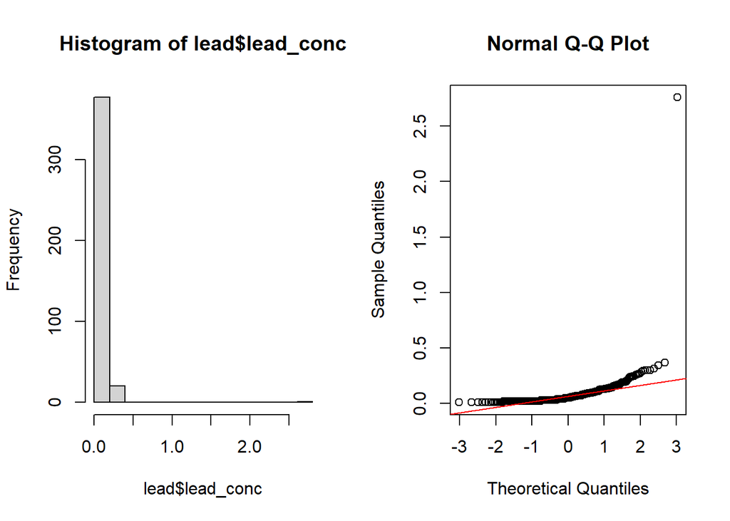

```r
par(mfrow = c(1, 2))

# First panel
hist(lead$lead_conc)

# Second panel
qqnorm(lead$lead_conc)
qqline(lead$lead_conc, col = "red")
```

```r
par(mfrow = c(1, 1))
```

There is one very strong outlier with a value of > 2.5 umol/L. This value would indicate a very severe level of lead poisoning (https://medlineplus.gov/ency/article/003360.htm). Let’s remove the outlier. However, we don’t have sufficient information to be able to judge whether this is a correct value or was a measurement error. Therefore the correct course of action is to make a decision, analyse the data and *then* re-analyze the data with the outlier included in case you decided to remove it in the previous step, or the other way around. You would use this second analysis to assess how strongly your *conclusions* are effected by your decision to keep/remove the outlier.

#### Step 3: For now, let’s remove the outlier and re-do step 2.

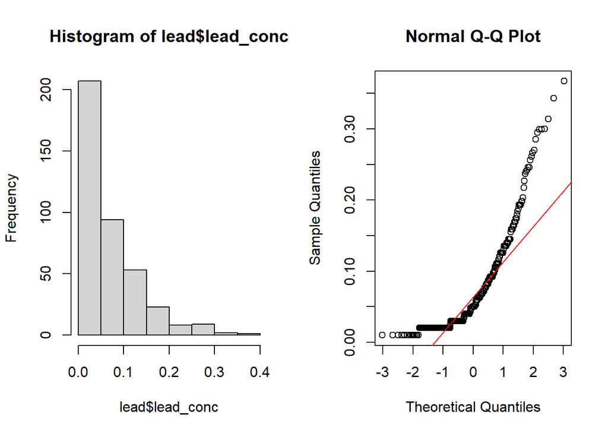

```r
# Remobe outlier
lead <- lead[lead$lead_conc < 1,]

# Plot the histogram and QQ plot
par(mfrow = c(1, 2))

# First panel
hist(lead$lead_conc)

# Second panel
qqnorm(lead$lead_conc)
qqline(lead$lead_conc, col = "red")
```

```r
par(mfrow = c(1, 1))
```

Clearly very skewed. Most people have low blood lead levels, but a minority of people has very high levels.

#### Step 4: Add a new column with log-transformed blood lead concentrations

Add a new column with log-transformed blood lead concentrations. You can’t take the log of zero, so check if there are people with blood lead levels of zero. If there are, take the log of `lead_conc` plus a small value (e.g., 0.01). Otherwise, just take the log of `lead_conc`.

```r
# Check if there are zero blood lead concentrations in the data
range(lead$lead_conc)
```

```
## [1] 0.010 0.367
```

```r
# Log-transform the data
lead$lead_log <- log(lead$lead_conc)
```

#### Step 5: Calculate the mean and standard deviation of the log-transformed blood lead concentrations.

Save both as a value in your R environment.

```r
mean_log_pop <- mean(lead$lead_log)
sd_sd_pop   <- sd(lead$lead_log)
```

#### Step 6: Check the distribution of blood lead concentrations

Plot a histogram with a normal distribution (mean and standard deviation of the population) plotted on top. Also plot a QQ plot. Plot both graphs side-by-side in a single graphical display.

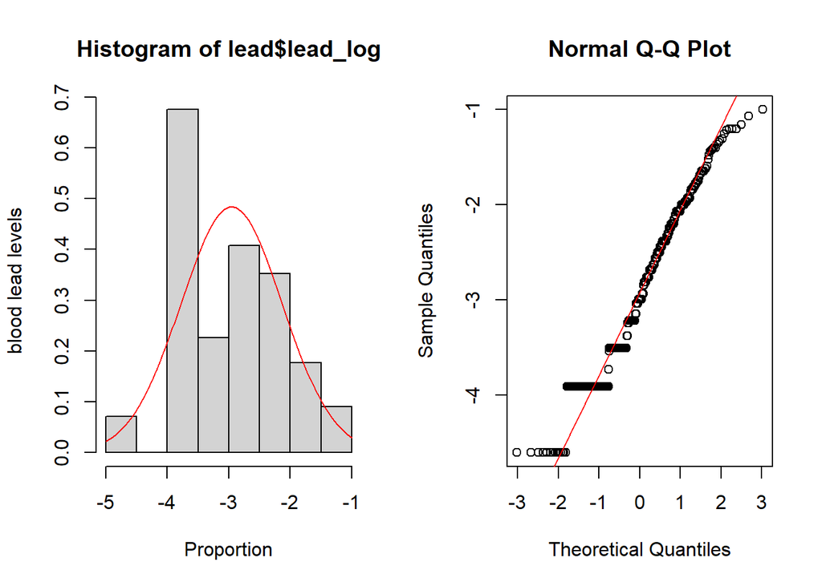

```r
par(mfrow = c(1, 2))

# Histogram with normal curve
hist(lead$lead_log,
     #breaks = seq(-5.0, -1.0, 0.2),
     freq = FALSE,
     ylab = "blood lead levels",
     xlab = "Proportion")
curve(dnorm(x, mean = mean_log_pop, sd = sd_sd_pop),
      from = -5.0,
      to = -1.0,
      add = TRUE,
      col = "red")

# QQ plot
qqnorm(lead$lead_log)
qqline(lead$lead_log, col="red")
```

```r
par(mfrow = c(1,1))
```

The data are still not normally distributed (there’s a hint of bimodality), and they are also truncated (that makes sense, blood lead levels can not be lower than zero)

#### Step 7: Assess if lead levels differ among ethnic groups

Does the mean blood lead levels differ among non-hispanic whites and non-hispanic blacks? Look at this for the years 2000 and 2018 separately.

```r
aggregate(lead_conc ~ ethn, data = lead[lead$year == 2000,], FUN = mean)
```

```
##                 ethn lead_conc
## 1 Non-Hispanic Black 0.1214925
## 2 Non-Hispanic White 0.0986250
```

```r
aggregate(lead_conc ~ ethn, data = lead[lead$year == 2018,], FUN = mean)
```

```
##                 ethn  lead_conc
## 1 Non-Hispanic Black 0.03207921
## 2 Non-Hispanic White 0.03735849
```

Just eyeballing the data, in 2000 the mean blood lead level of non-hispanic black participants was considerably higher then that of non-hispanic white participants. In 2018, means of the two ethic groups were very similar. Interestingly, mean blood lead levels more than halved over the 2000-2018 period. However, remember that the data was strongly skewed, so is the mean actually the best way of comparing the groups?

#### Step 8: Let’s do the same but now calculate the medians.

```r
aggregate(lead_conc ~ ethn, data = lead[lead$year == 2000,], FUN = median)
```

```
##                 ethn lead_conc
## 1 Non-Hispanic Black     0.106
## 2 Non-Hispanic White     0.070
```

```r
aggregate(lead_conc ~ ethn, data = lead[lead$year == 2018,], FUN = median)
```

```
##                 ethn lead_conc
## 1 Non-Hispanic Black      0.03
## 2 Non-Hispanic White      0.03
```

The differences in medians suggest higher lead levels in N-h blacks in 2000 but no difference in 2018. There is also a substantial decrease in median lead levels from 2000 to 2018.

#### Step 9: Use boxplots to compare groups

Now plot the data in box plots. Add appropriate x-axis and y-axis labels. Give the survey year as graph title. Use the `names =` argument to define the x-axis labels. Plot the two box plots side-to-side together in one graphical display.

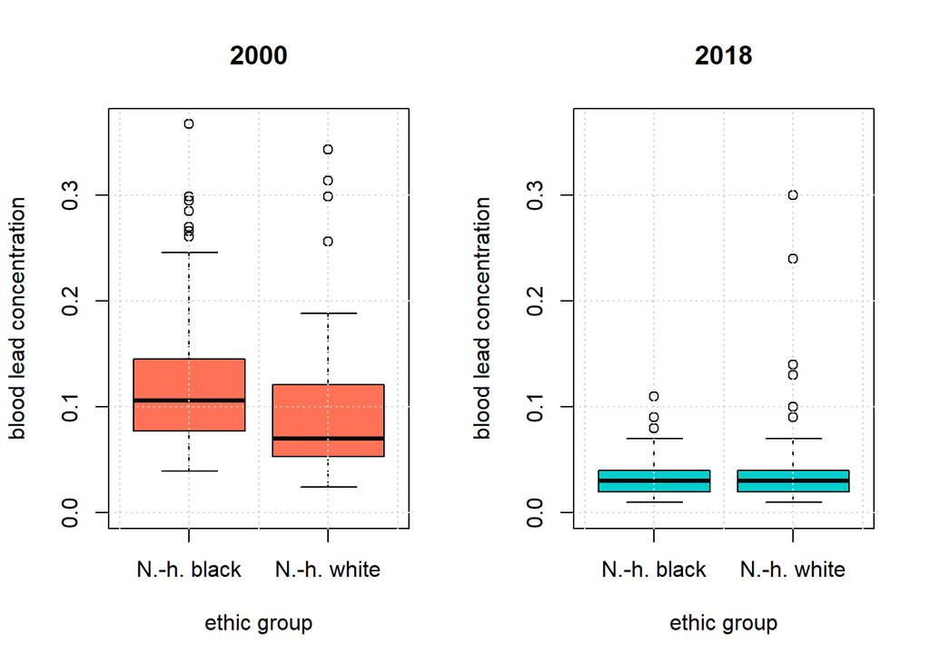

```r
par(mfrow = c(1,2))

boxplot(lead_conc ~ ethn,
        data = lead[lead$year == 2000, ],
        ylim = c(0, max(lead$lead_conc)),
        main = "2000",
        xlab = "ethic group",
        ylab = "blood lead concentration",
        names = c("N.-h. black", "N.-h. white"),
        col = "coral1")
grid()
boxplot(lead_conc ~ ethn,
        data = lead[lead$year == 2018, ],
        ylim = c(0, max(lead$lead_conc)),
        main = "2018",
        xlab = "ethic group",
        ylab = "blood lead concentration",
        names = c("N.-h. black", "N.-h. white"),
        col = "cyan3")
grid()
```

```r
par(mfrow = c(1,1))
```

The box plots show that the median blood lead concentration of 6-10 year old N-h black participants was higher than that of N-h white participants in 2000 and that this difference disappeared in 2018 (as we calculated before). Not only did the median blood lead concentrations decreased substantially, also the variation in blood lead concentrations among the participants decreased a lot.

Perhaps the average of blood lead levels is not the best metric for comparing the risk of exposure to lead between two groups. What may matter more is the proportion of children in each group that have blood lead levels above a certain threshold. The USA Centers for Disease Control and Prevention ( CDC, they are responsible for the annual Nhanes surveys) currently uses a blood lead reference value of 0.24 µmol/L to identify children who have been exposed to lead and who require further testing and monitoring. Please see their website for more information (shorturl.at/oAQ48). Let’s therefore compare the proportion of children in both ethic groups with lead levels above the 0.24 µmol/L threshold.

#### Step 10: Create new dataframe with data of children with high blood lead levels

Subset the dataframe `lead` to create a new data frame `lead_high` with only those children that had a blood lead concentration of 0.24 or higher.

```r
lead_high <- lead[lead$lead_conc >= 0.24,]
```

#### Step 11: Create tables with number of children per ethic group and survey year

Create two tables: one with the total number of children per ethnic group and survey year and one with the number of children with blood lead levels >= 0.24 per ethic group and year

```r
table_all_children            <- table(lead$ethn, lead$year)

table_children_with_high_lead <- table(lead_high$ethn, lead_high$year)

table_all_children
```

```
##
##                      2000 2018
##   Non-Hispanic Black  134  101
##   Non-Hispanic White   56  106
```

```r
table_children_with_high_lead
```

```
##
##                      2000 2018
##   Non-Hispanic Black   10    0
##   Non-Hispanic White    4    2
```

#### Step 12: calculate the percentage of children in each ethnic group and year with blood lead levels >= 0.24

Now use both tables to calculate the percentage of children in each ethnic group and year with blood lead levels >= 0.24

```r
100* table(lead_high$ethn, lead_high$year) / table(lead$ethn, lead$year)
```

```
##
##                          2000     2018
##   Non-Hispanic Black 7.462687 0.000000
##   Non-Hispanic White 7.142857 1.886792
```

No clear differences between the groups. However, the number of participants within the selected group (children 6-10 years old from low-income households) is really too low for this kind of questions and data. The study to which we referred in the beginning of this challenge used data form many more survey years, another age group and much more sophisticated statistical modeling techniques. Still, The activities of today demonstrate how you can explore your data and get a preliminary idea of relationships between variables and differences among groups with the basic R coding skills you have learned until now.